# 03 · Per-sample set scores

ssGSEA scores, tested on the design and read against the phenotype

`02_Set_Tests` asks whether a set moved in a contrast. This stage asks a different question: how much of each set is present in each sample. The output is one number per set per sample, a 1,040 × 131 matrix, and that turns a pathway into a variable that can be plotted against the muscle measurements rather than only reported with a p-value.

Two things are lost in the conversion and have to be said out loud. ssGSEA ranks within a sample, so the precision weights from limpa do not travel; a protein reconstructed largely from missing values carries the same rank as a well-measured one. And the scores are relative to the cohort: adding or removing samples changes them. Neither makes the scores wrong, but both mean the whole-set tests in `02_Set_Tests`, not these scores, carry error control for the contrasts.

```r
required <- c("here", "limma", "GSVA", "dplyr", "tibble", "tidyr", "purrr",
              "readr", "ggplot2")
missing <- required[!vapply(required, requireNamespace, logical(1), quietly = TRUE)]
if (length(missing)) stop("Install required R packages: ", paste(missing, collapse = ", "))
library(here)
library(limma)
library(dplyr)
library(tibble)
library(tidyr)
library(purrr)
library(ggplot2)
here::i_am("03_Pathway_Enrichment/03_Sample_Scores/a_script/03_sample_scores.qmd")

stage <- here("03_Pathway_Enrichment", "03_Sample_Scores")
out <- file.path(stage, "c_data")
dir.create(out, recursive = TRUE, showWarnings = FALSE)

x <- readRDS(here("03_Pathway_Enrichment", "01_Gene_Sets", "c_data", "pathway_inputs.rds"))
design <- x$design$design
contrasts <- x$design$contrasts
control <- x$design$negative_control
targets <- as_tibble(x$proteins$targets)

stopifnot(identical(colnames(x$gene_matrix), rownames(design)),
          all(vapply(x$gene_sets, \(g) all(g %in% rownames(x$gene_matrix)), logical(1))))
tibble(n_genes = nrow(x$gene_matrix), n_samples = ncol(x$gene_matrix),
       n_sets = length(x$gene_sets), negative_control = control)
```

| n_genes | n_samples | n_sets | negative_control |
| --- | --- | --- | --- |
| 3039 | 131 | 1040 | BFR_vs_HLRT_at_T1 |

## Scoring

`gene_matrix` is one fixed representative row per gene, chosen upstream without using any p-value or fold change, so the same representative serves every contrast.

```r
set.seed(42)
param <- GSVA::ssgseaParam(x$gene_matrix, x$gene_sets, minSize = 1, maxSize = Inf,
                           normalize = TRUE)
scores <- GSVA::gsva(param, verbose = FALSE)
stopifnot(identical(dim(scores), c(length(x$gene_sets), ncol(x$gene_matrix))),
          identical(colnames(scores), colnames(x$gene_matrix)),
          all(is.finite(scores)))
tibble(sets = nrow(scores), samples = ncol(scores),
       score_min = signif(min(scores), 3), score_median = signif(median(scores), 3),
       score_max = signif(max(scores), 3))
```

| sets | samples | score_min | score_median | score_max |
| --- | --- | --- | --- | --- |
| 1040 | 131 | -0.409 | 0.0732 | 0.591 |

## Testing the scores on the same design

The scores go into the same fixed-participant design, so a score is compared only within a person, exactly as the protein-level model does. No precision weights: they did not survive the ranking. `trend = TRUE` because set scores carry a mean-variance relationship of their own.

The negative control is read first here too. It is the same true null, and a score-level test that finds pathways between two untrained legs is telling us the same thing a protein-level one would.

```r
fit <- lmFit(scores, design) |> contrasts.fit(contrasts) |> eBayes(trend = TRUE)

score_results <- map(colnames(contrasts), \(cn) {
  topTable(fit, coef = cn, number = Inf, adjust.method = "none", sort.by = "none") |>
    rownames_to_column("set_id") |>
    transmute(set_id, contrast = cn, diff = logFC, t, p = P.Value)
}) |>
  list_rbind() |>
  separate_wider_delim(set_id, "|", names = c("database", "pathway"), cols_remove = FALSE) |>
  mutate(padj = p.adjust(p, "BH"), .by = c(contrast, database))

score_results |>
  summarise(sets = n(), sig = sum(padj < params$score_fdr),
            median_p = round(median(p), 3),
            p_below_05 = round(mean(p < 0.05), 3), .by = contrast) |>
  arrange(match(contrast, c(control, setdiff(colnames(contrasts), control))))
```

| contrast | sets | sig | median_p | p_below_05 |
| --- | --- | --- | --- | --- |
| BFR_vs_HLRT_at_T1 | 1040 | 0 | 0.510 | 0.032 |
| BFR_post_vs_pre | 1040 | 69 | 0.281 | 0.216 |
| HLRT_post_vs_pre | 1040 | 29 | 0.310 | 0.189 |
| BFR_vs_HLRT_at_T2 | 1040 | 0 | 0.467 | 0.062 |
| interaction | 1040 | 0 | 0.537 | 0.024 |

```r
score_results |>
  filter(contrast == control, padj < params$score_fdr) |>
  slice_min(padj, n = 15) |>
  transmute(database, pathway, diff = signif(diff, 3), padj = signif(padj, 3))
```

| database | pathway | diff | padj |
| --- | --- | --- | --- |

Sets above are false positives by construction. Compare the count with `02_Set_Tests`: if the score-level test is looser than `fry` on the same null, its results on the interaction inherit that looseness.

```r
score_results |>
  filter(database == "Hallmark", padj < params$score_fdr) |>
  arrange(contrast, padj) |>
  transmute(contrast, pathway, diff = signif(diff, 3), padj = signif(padj, 3))
```

| contrast | pathway | diff | padj |
| --- | --- | --- | --- |
| BFR_post_vs_pre | HALLMARK_OXIDATIVE_PHOSPHORYLATION | 0.0142 | 0.0126 |
| HLRT_post_vs_pre | HALLMARK_OXIDATIVE_PHOSPHORYLATION | 0.0132 | 0.0134 |
| HLRT_post_vs_pre | HALLMARK_SPERMATOGENESIS | -0.0145 | 0.0134 |
| HLRT_post_vs_pre | HALLMARK_ALLOGRAFT_REJECTION | 0.0178 | 0.0441 |

## Against the phenotype

This is what per-sample scores are for. A set whose change tracks the change in muscle cross-sectional area is worth more than a set with a small p-value, because the phenotype is the outcome the study was designed around.

The unit is a leg: one score change (T2 − T1) and one CSA change per leg. Correlation is computed **within each treatment separately**, so each person contributes one leg to each correlation and the observations are independent. Pooling both legs would put the same participant in twice.

Only sets that the score-level test flagged are correlated. Correlating all 1,040 against the phenotype would be several thousand tests chasing a handful of real relationships.

```r
pheno <- readr::read_csv(here("00_Input", "phenotype.csv"), show_col_types = FALSE) |>
  mutate(d_csa = vl_csa_post_cm2 - vl_csa_pre_cm2) |>
  select(participant, leg, treatment, d_csa)

score_long <- as_tibble(scores, rownames = "set_id") |>
  pivot_longer(-set_id, names_to = "sample_id", values_to = "score") |>
  left_join(select(targets, sample_id, participant, leg, treatment, timepoint),
            by = "sample_id")

delta <- score_long |>
  pivot_wider(id_cols = c(set_id, participant, leg, treatment),
              names_from = timepoint, values_from = score) |>
  filter(!is.na(T1), !is.na(T2)) |>
  mutate(d_score = T2 - T1) |>
  inner_join(pheno, by = c("participant", "leg", "treatment"))

tested_sets <- score_results |>
  filter(padj < params$score_fdr, contrast != control) |>
  distinct(set_id) |>
  pull(set_id)

correlations <- delta |>
  filter(set_id %in% tested_sets) |>
  summarise(
    n = n(),
    rho = cor(d_score, d_csa, method = "spearman"),
    p = cor.test(d_score, d_csa, method = "spearman", exact = FALSE)$p.value,
    .by = c(set_id, treatment)
  ) |>
  mutate(padj = p.adjust(p, "BH"), .by = treatment) |>
  separate_wider_delim(set_id, "|", names = c("database", "pathway"), cols_remove = FALSE)

tibble(sets_correlated = n_distinct(correlations$set_id),
       legs_per_treatment = paste(range(correlations$n), collapse = "-"),
       sig_BFR = sum(correlations$padj < 0.05 & correlations$treatment == "BFR"),
       sig_HLRT = sum(correlations$padj < 0.05 & correlations$treatment == "HLRT"))
```

| sets_correlated | legs_per_treatment | sig_BFR | sig_HLRT |
| --- | --- | --- | --- |
| 85 | 32-33 | 0 | 0 |

```r
correlations |>
  slice_min(padj, n = 20) |>
  arrange(padj) |>
  transmute(treatment, database, pathway, n, rho = round(rho, 3), padj = signif(padj, 3))
```

| treatment | database | pathway | n | rho | padj |
| --- | --- | --- | --- | --- | --- |
| HLRT | GOBP | GOBP_TUMOR_NECROSIS_FACTOR_SUPERFAMILY_CYTOKINE_PRODUCTION | 33 | 0.530 | 0.129 |
| HLRT | Reactome | REACTOME_TRNA_AMINOACYLATION | 33 | 0.453 | 0.192 |
| HLRT | GOBP | GOBP_AMINO_ACID_METABOLIC_PROCESS | 33 | 0.482 | 0.192 |
| HLRT | GOBP | GOBP_POSITIVE_REGULATION_OF_CYTOSOLIC_CALCIUM_ION_CONCENTRATION | 33 | -0.448 | 0.192 |
| HLRT | Reactome | REACTOME_REGULATION_OF_CHOLESTEROL_BIOSYNTHESIS_BY_SREBP_SREBF | 33 | 0.404 | 0.229 |
| HLRT | GOBP | GOBP_CARBOXYLIC_ACID_TRANSMEMBRANE_TRANSPORT | 33 | 0.399 | 0.229 |
| HLRT | GOBP | GOBP_FATTY_ACID_METABOLIC_PROCESS | 33 | 0.400 | 0.229 |
| HLRT | GOBP | GOBP_REGULATION_OF_MUSCLE_SYSTEM_PROCESS | 33 | -0.416 | 0.229 |
| HLRT | GOBP | GOBP_MITOCHONDRIAL_RNA_METABOLIC_PROCESS | 33 | 0.379 | 0.252 |
| HLRT | GOBP | GOBP_MONOCARBOXYLIC_ACID_CATABOLIC_PROCESS | 33 | 0.381 | 0.252 |
| HLRT | GOBP | GOBP_BRANCHED_CHAIN_AMINO_ACID_METABOLIC_PROCESS | 33 | 0.365 | 0.283 |
| HLRT | GOBP | GOBP_POSITIVE_REGULATION_OF_PATTERN_RECOGNITION_RECEPTOR_SIGNALING_PATHWAY | 33 | 0.345 | 0.349 |
| HLRT | GOBP | GOBP_CANONICAL_NF_KAPPAB_SIGNAL_TRANSDUCTION | 33 | -0.333 | 0.380 |
| HLRT | GOBP | GOBP_NUCLEOSIDE_PHOSPHATE_BIOSYNTHETIC_PROCESS | 33 | 0.324 | 0.399 |
| HLRT | GOBP | GOBP_POSITIVE_REGULATION_OF_GROWTH | 33 | -0.301 | 0.500 |
| HLRT | Reactome | REACTOME_CITRIC_ACID_CYCLE_TCA_CYCLE | 33 | 0.283 | 0.519 |
| HLRT | GOBP | GOBP_HEART_MORPHOGENESIS | 33 | -0.285 | 0.519 |
| HLRT | GOBP | GOBP_MITOCHONDRIAL_GENE_EXPRESSION | 33 | 0.289 | 0.519 |
| HLRT | Reactome | REACTOME_MITOCHONDRIAL_PROTEIN_DEGRADATION | 33 | 0.265 | 0.526 |
| HLRT | GOBP | GOBP_PROTEIN_AUTOPHOSPHORYLATION | 33 | 0.269 | 0.526 |
| HLRT | GOBP | GOBP_PROTEIN_IMPORT_INTO_MITOCHONDRIAL_MATRIX | 33 | 0.265 | 0.526 |
| HLRT | GOBP | GOBP_TRNA_METABOLIC_PROCESS | 33 | 0.273 | 0.526 |

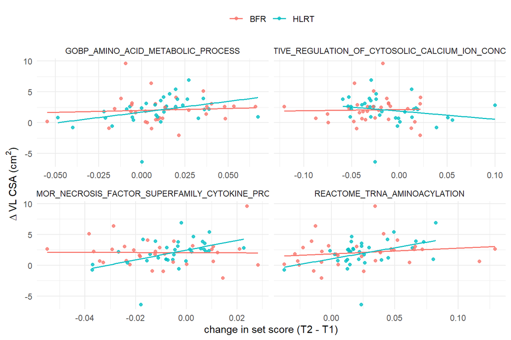

```r
top <- correlations |> slice_min(padj, n = 4) |> pull(set_id) |> unique()
if (length(top)) {
  delta |>
    filter(set_id %in% top) |>
    mutate(pathway = sub("^[^|]+\\|", "", set_id)) |>
    ggplot(aes(d_score, d_csa, colour = treatment)) +
    geom_point(alpha = 0.8) +
    geom_smooth(method = "lm", se = FALSE, linewidth = 0.6, formula = y ~ x) +
    facet_wrap(~pathway, scales = "free_x", labeller = label_wrap_gen(34)) +
    labs(x = "change in set score (T2 - T1)", y = expression(Delta ~ "VL CSA (cm"^2 * ")"),
         colour = NULL) +
    theme_minimal() +
    theme(legend.position = "top")
}
```

A correlation here is a relationship between two changes measured on the same leg, not evidence that the pathway caused the growth. Both would move together under any shared upstream cause, including how much that leg was loaded.

## Export

```r
saveRDS(scores, file.path(out, "set_scores.rds"))
readr::write_csv(score_results, file.path(out, "score_contrast_results.csv"))
readr::write_csv(correlations, file.path(out, "score_phenotype_correlations.csv"))
tibble(file = list.files(out), bytes = file.size(file.path(out, list.files(out))))
```

| file | bytes |
| --- | --- |
| score_contrast_results.csv | 968541 |
| score_phenotype_correlations.csv | 26711 |
| set_scores.rds | 1175323 |